# Advancing in R: A guide for Biologists and Ecologists

# Day 3 Block 8: Github

## 7.13 Let's Git it started

Git is a **version control system**. Originally built to help groups of developers work collaboratively on big software projects. It helps us manage our RStudio projects - with tracked changes.

Git and GitHub are a big part of the data science community. We can use GitHub in a number of ways

1. To source code and repurpose analyses built by others for our own uses
2. Manage our analysis projects so that all parts of it:

   🔢 Data

   ✍ ️Scripts

   📊 Figures

   📝 Reports

Are version controlled and open access

3. Version control lets you recover from any mistakes & your analysis is *backed up* externally
4. When you come to publish any reports - your analysis is accessible to others
5. Build up your own library of projects to show what you can do in Data Science

If you work alone, git is great to track changes and recover previous version of your files. You can also use a remote repository to have a back up and share your work.

If you work as a team you can take advantage of all the above and also use version control as a tool to collaborate and organize the various versions of the same file present in the multiple computers you and they use.

## 7.14 What is version control?

Let’s imagine that we have a git repository. When you create a new file as part of the repository (or repo), that file is untracked. This means that git will ignore the file and any change you make to it *until you add it to the repo*. At that point the file is **staged** and ready to get into the repository. To do that you do a **commit** and save that version of the file to the repo. This workflow `modify --> add --> commit` will repeat every time you want to save a version of the file. It's a good idea to commit every time you end a task or objective in your project.

[figure not shown]

`add` and `commit` are also git commands.RStudio provides a basic GUI for git, which we are going to use in this workshop. But you can also use the Terminal to talk to git on the command line

to add a file to the staging area.

git add

git commit -m “A descriptive message to commit the files on the staging area.”

## 7.15 Remote repositories

What we explained before is the local workflow. This is when the repo lives in your computer and that’s it. But you can also connect the local repository with a remote repository. For this workshop we are going to use [GitHub](https://github.com/) to host remote repositories, but there are other options you can explore, such as [GitLab](https://about.gitlab.com/).

Let’s imagine we have a local repository, we made some commits and we want to send those changes to the remote repository (we’ll how to create the remote repository later). For that we push the commits to the remote repository and the two repos are “up to date”.

If a team-mate changes a file and pushes the changes it to the remote repository, your local repo will be “outdated”. To download those new commits from the remote repository you pull the commits.

[figure not shown]

And if you want to try the command line:

```
# to upload commits to the remote repository.

git push

# to download commits from the remote repository to the local repo.

git pull
```

## 7.16 Git introductions

Before you create your first repository you need to make sure that git and RStudio are friends and that git knows you. That means you have:

- [Installed Git on your machine](https://git-scm.com/book/en/v2/Getting-Started-Installing-Git) (not needed if using Posit Cloud)
- Created a free Github Account - go to [github.com](https://github.com/)

You can check that RStudio “sees” git by going to Tools –> Global Options –> Git/SVN. There you should find the path in your computer to the git installation.

You can now introduce yourself to Github with the `usethis` package

```r
library(usethis)
use_git_config(user.name  = "Jane Doe",
               user.email = "jane@example.org")
```

Substituting with your name and the email associated with your GitHub account, or you can also do this on the command line:

git config –global user.name ‘Jane Doe’

git config –global user.email ’jane@example.com

You will also need a Personal Access Token (PAT), Github has started using these *in lieu* of passwords.

Create a PAT with

```r
usethis::create_github_token()
```

This will likely open a new window allowing you to create a token. Do now close this window, as you will need to copy the token to your clipboard. Then run this other command:

```r
gitcreds::gitcreds_set()
```

This will ask you for your access token. Go to the previous window, copy the token, paste it on your console and press enter.

Finally, to check that everything’s ok with this command.

```r
usethis::gh_token_help()
```

Irritatingly the PAT seems to be forgotten on linux systems very quickly, which is what Posit Cloud is hosted on:

A simple solution to this problem is to ask git to store information in the cache for just a teeny tiny little bit longer. Instead of having the cache expire after the default 900 seconds, maybe set it to expire after 10 million seconds. That way, you’ll only have to refresh the cache using gitcreds::gitcreds_set() once every four months instead of four times an hour. Implementing this solution requires only one line of code at the terminal:

```
git config --global credential.helper 'cache --timeout=10000000'
```

Thanks to https://blog.djnavarro.net/posts/2021-08-08_git-credential-helpers/ for this bit of information!

> If the system ever forgets your username or PAT, you should be able to paste these into prompts when pushing as well.

## 7.17 Create a new repository

There are many ways to start a new repository, the easiest is *Github first*

### 7.17.1 1. Create an online repository.

- Go to github.com and log in.
- On the top right corner, click on the “+” bottom and then “New repository”

Then:

- Repository template: No template.
- Repository name: myrepo or whatever you wish to name your new project.
- Description: Any short description of the project. Write this for humans.
- Public.
- Initialize this repository with: nothing (we can set up everything from R).

Before going back to RStudio, copy the url for the repository.

### 7.17.2 2. Clone into RStudio

- File > New Project > Version Control > Git. In the “repository URL” paste the URL of your new GitHub repository
- Choose the folder where you want to create the project.
- Choose “Open in new session”.
- And Click on “Create Project”.

The new folder in your computer will be a git repository, linked to a remote GitHub repository and an RStudio Project at the same time. This workflow also makes sure that all the configuration between the local and remote repos are done correctly.

It also adds a `.gitignore` file that includes a list of files that we don’t need to track (i.e. .Rhistory).

The .gitignore file can be a good place to store your PAT file. Make a plain text file and write in your token code, save it as anything you like e.g. token.txt. Add the name of this to your .gitignore file and it will save locally but never be pushed to your repo. Watch the Git pane in Rstudio to check it is not being tracked.

### 7.17.3 Local changes

- Create a new .Rmd/.Qmd file
- Save the file
- Add it to the staging area by selecting the file in the Git pane
- Select commit and write a descriptive message in the commit message pane

At this point you should be able to see all the files in the staging area, and by selecting each one, the line by line differences in any changes you have made since your last commit

[figure not shown]

## 7.18 See changes

The first and most immediate benefit of using GitHub with your RStudio Project is seeing the changes you have made since your last commit.

The RStudio Git pane lists every file that’s been added, modified or deleted. The icon describes the change:

- You've changed a file

[figure not shown]

- You've added a new file Git hasn't seen before

[figure not shown]

- You've deleted a file

[figure not shown]

You can get more details on the changes that have been made to each file by right-clicking and selecting diff

[figure not shown]

This opens a new window highlighting the **diff**erences between your current file and the previous commit.

[figure not shown]

The background colours tells you whether the text has been added (green) or removed (red). (If you’re colourblind you can use the line numbers in the two columns at the far left as a guide).

## 7.19 Remote changes

**Now Push** - push your commits to the remote repository. You won't see any changes on Github until you push those commits.

Let's head back to GitHub now. If you refresh the page, now you’ll see the files you committed just now. Let’s click on “Commits” to see the history of the repository. From this view, you can explore the repository at the “state” of each commit and look at the file differences.

Now, we can try to make changes here at github.com

### 7.19.1 Create a README

- On the main page, click on the green bottom that says “Add a README”.
- Add something to the file. READMEs usually are written in Markdown and contain information about the repo.
- At the end of the page add a message on the first line and click on “Commit new file”.
- Come back to the main page to see the README.

The new file and the changes you do on GitHub are only on the remote repository until you make a pull from the local repo. If you make changes on the local repo while it not up to date, you may encounter **merge conflicts**, which lead to headaches. This happens when the version of a file on the local repo is not compatible with its version on the remote repo. In those cases, git cannot decide which version is the right one and you have to do it yourself.

To avoid this problem (most of the time), you should do a **pull everytime you load up a project** before doing anything else. Most of the time the message will be "Already up to-date", but this is a good habit.

Now we should head to the GitPane in RStudio and select the blue "Pull" button. The README should appear in your files.

## 7.20 Working with branches

Using Git branches in RStudio allows you to work on different features, experiments, or manuscript sections independently without affecting the main codebase. This is particularly useful in scientific research for trying out new analysis methods, writing different parts of a paper, or making bug fixes without disrupting ongoing work.

### 7.20.1 Create a new branch in Rstudio

Go to the `Terminal` and run the following command:

```
git checkout -b new-plot
```

### 7.20.2 Create a new branch in Github

- Click on the "main" branch drop-down menu (or the current branch name).
- Type the name of your new branch into the text field and press Enter to create it.

[figure not shown]

### 7.20.3 Working on a new branch

Make Changes: Edit your files as needed on this branch.

Stage and Commit and Push changes as usual

In the Git pane, click on the Branch drop-down menu and select the branch you wish to use to switch between branches effortlessly

**Task**

Add a new plot to your file - hist(cars$speed)

### 7.20.4 Merge branches

Pull request and merge changes Now go back to your repo on GitHub. You will notice that at the top of all you files there is a new section that says: Your recently pushed branches: The changes you made to your script have been pushed to your online copy of the project and are now in the branch feature. In order to merge them into your master branch we need to create a pull request.

Click on the button that says *Compare and pull request**.

In the Open a pull request page click on Create pull request.

[figure not shown]

Github will now compare the two versions of your project that are in the two branches, master/main and NewPlot and it is telling us that there are no conflicts between the two versions.

[figure not shown]

Now it’s time to bring your changes together – merging your NewPlot branch into the main branch. Click the green Merge pull request button to merge the changes into main. Click Confirm merge. Go ahead and delete the branch, since its changes have been incorporated, with the Delete branch button in the purple box.

[figure not shown]

### 7.20.5 Summary

You can create and manage Git branches either from RStudio or directly on GitHub. In RStudio, use the terminal to create branches and manage them through the Git pane. On GitHub, you can create branches and manage them using the web interface, which also supports pull requests for merging changes. Using branches helps you work on features or fixes independently, keeping your main branch clean and stable.

> Keep Branches short and prune them often, you have to manually fix any conflicts - and this is much simpler when branches are short and focused

## 7.21 Collaborating on a repo

When collaborating on a project you can find yourself in one of two scenarios

- You have write permission of the repo you are working on.
- You don’t have write permission on the repo.

The first situation is the most common when working together with an team on a long term project. You can clone the repo following the these same instructions and use the same workflow as before. When you try to push your changes to the remote repository, GitHub will check if you have the rights to modify the repo. The only difference between this and working on your own is that you need to **communicate well so that two people are not working on the same thing**. Otherwise this will lead to **merge conflicts**.

The second situation is common when contributing to strangers' projects, such as fixing bugs in open source packages. In this case, you need to first fork the repository, which creates a remote repository linked to your GitHub account to which you will have complete access. Now you work in this fork using the normal workflow: modify, add, commit and push. But for your changes to integrate into the original repository, you need to create a pull request (or PR). This will let the owner of the original repo that you made some changes that you think should be merged. The owner can then accept, reject or ask for modifications. Once they accept your Pull Request, your modifications will be safe in the original repository.

### 7.21.1 Working with an external collaborator

**1.** Go to [github.com](https://github.com/) and log in (you need your own account - for sign up with your uea.ac.uk e-mail)

**2.** In the Search bar, look for repo **Philip-Leftwich/5023Y-Happy-Git**

**3.** Click on the repo name, and look at the existing repo structure

**4.** **FORK** the repo

### 7.21.2 What the hell is a fork?

[figure not shown]

A fork is when you generate a *personal* copy of another user's repository.

**5.** Press Clone/download and copy the URL, then create a **new** project in RStudio Cloud selecting the **New project from Git repository** option - make sure you are in the 5023Y Workspace

[figure not shown]

**6.** Open the some_cool_animals.Rmd document, and the accompanying html

**7.** Add *your name* to the top of the document

**8.** BUT WAIT. We have forgotten to add YOUR favourite animal and facts! Make a new tab in the markdown file add an image and some information

**9.** Once you’ve added your updates, knit the Rmd document to update the html

**10.** Stage, Commit & Push all files (glossary)

Staged - pick those files which you intend to bind to a commit

Commit - write a short descriptive message, binds changes to a single commit

Push - "Pushes" your changes from the local repo to the remote repo on GitHub, (push)

**11.** On GitHub, refresh and see that files are updated. Cool! Now you’ve used something someone else has created, customized it, and saved your updated version.

### 7.21.3 Make a pull request

**1.** Go to your repo in GitHub, you will see that you made the last commit and a message about being ahead of my project:

**2.** Click on “Open pull request”.

**3.** And click on “Create pull request”.

**4.** We are almost there. Complete the pull request with a title and a message and then finish the pull request.

The owner/s of the repo will receive an email. They can review the pull request, comment on it and eventually accept the contribution. When that happen the changes you made will appear in their repo.

## 7.22 A couple of general tips:

- Pull at the start of **every session** this retrieves the master repo from GitHub - which you update at the end of every session. This helps prevent *conflicts*
- **Commit/push** in small, meaningful increments and do this often. You can make **multiple** commits in a session - and **always push at the end of the session**
- In this way your GitHub Repo becomes the **master copy** of your project.

## 7.23 Beautify your profile

You can share information about yourself with the community on GitHub.com by creating a profile README. GitHub shows your profile README at the top of your profile page.

You decide what information to include in your profile README, so you have full control over how you present yourself on GitHub. Here are some examples of information that visitors may find interesting, fun, or useful in your profile README.

An "About me" section that describes your work and interests

Contributions you're proud of, and context about those contributions

Guidance for getting help in communities where you're involved

[figure not shown]

Handy links:

https://dev.to/ruppysuppy/beautify-your-github-profile-like-a-pro-5093

https://docs.github.com/en/account-and-profile/setting-up-and-managing-your-github-profile/customizing-your-profile/managing-your-profile-readme

## 7.24 Version releases

Creating tags in Git is a great way to mark specific points in your project's history, such as a version release, manuscript submission, or any significant milestone. Tags are immutable references to a specific commit, unlike branches that can move as you add new commits. This is especially useful in research projects to keep track of the exact state of your analysis or code at key moments

https://docs.github.com/en/repositories/releasing-projects-on-github/managing-releases-in-a-repository

Individual releases can have a doi assigned to them via Zenodo or Figshare - so that they can accompany your papers and use them to represent different stages of publication (e.g. preprint or peer-reviewed manuscript)

### 7.24.1 Get a DOI from your Github project

With a well organised and contained analysis project made into a repository on Github it becomes a one-click button process to generate a permanent DOI through repositories such as [Zenodo](https://zenodo.org/) or [Figshare](https://figshare.com/). A great payoff for having spent the time organising your projects from the beginning!

[figure not shown]

## 7.25 Glossary-GitHub

| Terms | Description |
| --- | --- |
| clone | A clone is a copy of a repository that lives on your computer instead of on a website's server somewhere, or the act of making that copy. When you make a clone, you can edit the files in your preferre… |
| commit | A commit, or revision, is an individual change to a file (or set of files). When you make a commit to save your work, Git creates a unique ID that allows you to keep record of the specific changes com… |
| commit message | Short, descriptive text that accompanies a commit and communicates the change the commit is introducing. |
| fork | A fork is a personal copy of another user's repository that lives on your account. Forks allow you to freely make changes to a project without affecting the original upstream repository. You can also … |
| Git | Git is an open source program for tracking changes in text files. It was written by the author of the Linux operating system, and is the core technology that GitHub, the social and user interface, is … |
| GitHub Classroom | GitHub Classroom automates repository creation and access control, making it easy to distribute starter code and collect assignments on GitHub |
| Markdown | Markdown is an incredibly simple semantic file format, not too dissimilar from .doc, .rtf and .txt. Markdown makes it easy for even those without a web-publishing background to write prose (including … |
| pull | Pull refers to when you are fetching in changes and merging them. For instance, if someone has edited the remote file you're both working on, you'll want to pull in those changes to your local copy so… |
| push | To push means to send your committed changes to a remote repository on GitHub.com. For instance, if you change something locally, you can push those changes so that others may access them. |
| README | A text file containing information about the files in a repository that is typically the first file a visitor to your repository will see. A README file, along with a repository license, contribution … |
| repository | A repository (repo) is the most basic element of GitHub. They're easiest to imagine as a project's folder. A repository contains all of the project files (including documentation), and stores each fil… |
| RMarkdown | Rmarkdown is a package and filetype that are deeply embedded with RStudio to allow the integration of Markdown and output chunks of programming code (such as R) to publish a variety of different file … |
| personal access token | A token that is used in place of a password when performing Git operations over HTTPS. Also called a PAT. |

## 7.26 Reading

- [Happy Git](https://happygitwithr.com/)

## 7.27 BONUS EXERCISE

This is a great exercise in practising dealing with merge conflicts when collaborating. To complete this exercise you will need a partner

https://learning.nceas.ucsb.edu/2023-04-coreR/session_10.html

## 7.28 Making tables with gt

In this chapter, we will accomplish two main objectives:

1. Acquire fundamental principles for creating improved tables.
2. Apply these principles using the `gt` package. Naturally, to put these ideas into practice, we'll utilize the fantastic penguins dataset from `palmerpenguins` since I have a preference for penguins.

PROS: Why `gt`? Has a grammar of tables, like `ggplot2`, supports HTML, Latex and RTF, followstidyverse conventions.

CONS: Still quite new, syntax is changing and developing.

For these tutorials we will use the `gt` package and helpers provided by `gtExtras`.

To follow along when you run a section of code, look for the output in the **Viewer Pane**

```r
library(gt)
library(gtExtras)
```

Let's use this dataset to tally the penguins. These counts will provide us with a straightforward dataset to use for practicing table construction. You will need your cleaned penguins dataframe from Day One.

```r
penguin_counts <- penguins |>
  drop_na(sex) |>
  mutate(year = as.character(year)) |>
  mutate(sex = str_to_lower(sex)) |>
  group_by(species, island, sex, year) |>
  summarise(n = n(), .groups = "drop")

penguin_counts
```

| species | island | sex | year | n |
| --- | --- | --- | --- | --- |
| Adelie | Biscoe | female | 2007 | 5 |
| Adelie | Biscoe | female | 2008 | 9 |
| Adelie | Biscoe | female | 2009 | 8 |
| Adelie | Biscoe | male | 2007 | 5 |
| Adelie | Biscoe | male | 2008 | 9 |
| Adelie | Biscoe | male | 2009 | 8 |
| Adelie | Dream | female | 2007 | 9 |
| Adelie | Dream | female | 2008 | 8 |
| Adelie | Dream | female | 2009 | 10 |
| Adelie | Dream | male | 2007 | 10 |
| Adelie | Dream | male | 2008 | 8 |
| Adelie | Dream | male | 2009 | 10 |
| Adelie | Torgersen | female | 2007 | 8 |
| Adelie | Torgersen | female | 2008 | 8 |
| Adelie | Torgersen | female | 2009 | 8 |
| Adelie | Torgersen | male | 2007 | 7 |
| Adelie | Torgersen | male | 2008 | 8 |
| Adelie | Torgersen | male | 2009 | 8 |
| Chinstrap | Dream | female | 2007 | 13 |
| Chinstrap | Dream | female | 2008 | 9 |
| Chinstrap | Dream | female | 2009 | 12 |
| Chinstrap | Dream | male | 2007 | 13 |
| Chinstrap | Dream | male | 2008 | 9 |
| Chinstrap | Dream | male | 2009 | 12 |
| Gentoo | Biscoe | female | 2007 | 16 |
| Gentoo | Biscoe | female | 2008 | 22 |
| Gentoo | Biscoe | female | 2009 | 20 |
| Gentoo | Biscoe | male | 2007 | 17 |
| Gentoo | Biscoe | male | 2008 | 23 |
| Gentoo | Biscoe | male | 2009 | 21 |

In a real table, the data might be restructured for better readability. While there's nothing inherently wrong with the long (i.e., containing many rows) data format, this format is excellent for data analysis. However, in a table intended for human readers, rather than machines, you'd likely opt for a wider format.

```r
penguin_counts_wider <- penguin_counts |>
  pivot_wider(
    names_from = c(species, sex),
    values_from = n
  ) |>
  # Make missing numbers (NAs) into zero
  mutate(across(.cols = -(1:2), ~replace_na(., replace = 0))) |>
  arrange(island, year)

penguin_counts_wider
```

| island | year | Adelie_female | Adelie_male | Chinstrap_female | Chinstrap_male | Gentoo_female | Gentoo_male |
| --- | --- | --- | --- | --- | --- | --- | --- |
| Biscoe | 2007 | 5 | 5 | 0 | 0 | 16 | 17 |
| Biscoe | 2008 | 9 | 9 | 0 | 0 | 22 | 23 |
| Biscoe | 2009 | 8 | 8 | 0 | 0 | 20 | 21 |
| Dream | 2007 | 9 | 10 | 13 | 13 | 0 | 0 |
| Dream | 2008 | 8 | 8 | 9 | 9 | 0 | 0 |
| Dream | 2009 | 10 | 10 | 12 | 12 | 0 | 0 |
| Torgersen | 2007 | 8 | 7 | 0 | 0 | 0 | 0 |
| Torgersen | 2008 | 8 | 8 | 0 | 0 | 0 | 0 |
| Torgersen | 2009 | 8 | 8 | 0 | 0 | 0 | 0 |

Here are six guidelines that will guide us as we make tables:

1. Avoid gridlines
2. Use better column names
3. Align columns
4. Use groups instead of repetitive columns
5. Remove missing numbers
6. Add summaries

### 7.28.1 Avoid vertical lines

Vertical lines can make our data look cramped. Fortunately, it appears that `gt` adheres to this principle by default. Hence, all we need to do is supply our dataset, `penguin_counts_wider`, to the `gt()` function.

```r
penguin_counts_wider |>
  gt()
```

| island | year | Adelie_female | Adelie_male | Chinstrap_female | Chinstrap_male | Gentoo_female | Gentoo_male |
| --- | --- | --- | --- | --- | --- | --- | --- |
| Biscoe | 2007 | 5 | 5 | 0 | 0 | 16 | 17 |
| Biscoe | 2008 | 9 | 9 | 0 | 0 | 22 | 23 |
| Biscoe | 2009 | 8 | 8 | 0 | 0 | 20 | 21 |
| Dream | 2007 | 9 | 10 | 13 | 13 | 0 | 0 |
| Dream | 2008 | 8 | 8 | 9 | 9 | 0 | 0 |
| Dream | 2009 | 10 | 10 | 12 | 12 | 0 | 0 |
| Torgersen | 2007 | 8 | 7 | 0 | 0 | 0 | 0 |
| Torgersen | 2008 | 8 | 8 | 0 | 0 | 0 | 0 |
| Torgersen | 2009 | 8 | 8 | 0 | 0 | 0 | 0 |

### 7.28.2 Use better column names and make them stand out

The [`cols_*()` functions](https://gt.rstudio.com/reference/index.html#section-modify-columns) allow for modifications of entire columns.

We can control the column labels, cell alignment, column width and placement plus can combine multiple columns with `cols_*()` functions.

```r
penguin_counts_wider |>
  gt() |>
  cols_label(
    island = 'Island',
    year = 'Year',
    Adelie_female = 'Adelie (female)',
    Adelie_male = 'Adelie (male)',
    Chinstrap_female = 'Chinstrap (female)',
    Chinstrap_male = 'Chinstrap (male)',
    Gentoo_female = 'Gentoo (female)',
    Gentoo_male = 'Gentoo (male)',
  )
```

| Island | Year | Adelie (female) | Adelie (male) | Chinstrap (female) | Chinstrap (male) | Gentoo (female) | Gentoo (male) |
| --- | --- | --- | --- | --- | --- | --- | --- |
| Biscoe | 2007 | 5 | 5 | 0 | 0 | 16 | 17 |
| Biscoe | 2008 | 9 | 9 | 0 | 0 | 22 | 23 |
| Biscoe | 2009 | 8 | 8 | 0 | 0 | 20 | 21 |
| Dream | 2007 | 9 | 10 | 13 | 13 | 0 | 0 |
| Dream | 2008 | 8 | 8 | 9 | 9 | 0 | 0 |
| Dream | 2009 | 10 | 10 | 12 | 12 | 0 | 0 |
| Torgersen | 2007 | 8 | 7 | 0 | 0 | 0 | 0 |
| Torgersen | 2008 | 8 | 8 | 0 | 0 | 0 | 0 |
| Torgersen | 2009 | 8 | 8 | 0 | 0 | 0 | 0 |

However, labeling the columns in this manner may not be the most effective approach. Let's explore an alternative method. First, we can create what are known as "spanners," which are merged columns.

We can modify the look of table parts more generally with [tab_*()] functions

Here we can generate column spanners with `tab_spanner()` layers, with one layer dedicated to each spanner. You can also control text formatting of labels with Markdown or HTML syntax. This can be used on any text in a **gt** table. Here I have applied some `md` to put my spanners in **bold**.

```r
penguin_counts_wider |>
  gt() |>
  cols_label(
    island = 'Island',
    year = 'Year',
    Adelie_female = 'Adelie (female)',
    Adelie_male = 'Adelie (male)',
    Chinstrap_female = 'Chinstrap (female)',
    Chinstrap_male = 'Chinstrap (male)',
    Gentoo_female = 'Gentoo (female)',
    Gentoo_male = 'Gentoo (male)',
  ) |>
  # md() function applies markdown styling - we can make text bold
  tab_spanner(
    label = md('**Adelie**'),
    columns = 3:4
  ) |>
  tab_spanner(
    label = md('**Chinstrap**'),
    columns = c('Chinstrap_female', 'Chinstrap_male')
  ) |>
  tab_spanner(
    label =  md('**Gentoo**'),
    columns = contains('Gentoo')
  )
```

| Island | Year | **Adelie** Adelie (female) | **Adelie** Adelie (male) | **Chinstrap** Chinstrap (female) | **Chinstrap** Chinstrap (male) | **Gentoo** Gentoo (female) | **Gentoo** Gentoo (male) |
| --- | --- | --- | --- | --- | --- | --- | --- |
| Biscoe | 2007 | 5 | 5 | 0 | 0 | 16 | 17 |
| Biscoe | 2008 | 9 | 9 | 0 | 0 | 22 | 23 |
| Biscoe | 2009 | 8 | 8 | 0 | 0 | 20 | 21 |
| Dream | 2007 | 9 | 10 | 13 | 13 | 0 | 0 |
| Dream | 2008 | 8 | 8 | 9 | 9 | 0 | 0 |
| Dream | 2009 | 10 | 10 | 12 | 12 | 0 | 0 |
| Torgersen | 2007 | 8 | 7 | 0 | 0 | 0 | 0 |
| Torgersen | 2008 | 8 | 8 | 0 | 0 | 0 | 0 |
| Torgersen | 2009 | 8 | 8 | 0 | 0 | 0 | 0 |

As you can see, tab_spanner() always requires two arguments label and columns. For the columns argument I have shown you three ways to get the job done:

1. Vector of column numbers
2. Vector of column names
3. tidyselect helpers

First, we no longer need the species labels in the actual column names, as the spanners already provide that information. To update the column names, we can employ a handy trick that will save us from tedious typing.

Begin by creating a named vector that establishes a connection between the original column names, which include species labels, and the desired column names that exclude those labels. For example:

```r
desired_colnames <- colnames(penguin_counts_wider) |>
  str_remove("(Adelie|Gentoo|Chinstrap)_") |>
  str_to_title()

names(desired_colnames) <- names(penguin_counts_wider)
```

With this named vector in place, proceed to rename the columns using it in the .list argument in `cols_label()`

```r
penguin_counts_wider |>
    gt() |>
  cols_label(.list = desired_colnames) |>
  # md() function applies markdown styling - we can make text bold
  tab_spanner(
    label = md('**Adelie**'),
    columns = 3:4
  ) |>
  tab_spanner(
    label = md('**Chinstrap**'),
    columns = c('Chinstrap_female', 'Chinstrap_male')
  ) |>
  tab_spanner(
    label =  md('**Gentoo**'),
    columns = contains('Gentoo')
  )
```

| Island | Year | **Adelie** Female | **Adelie** Male | **Chinstrap** Female | **Chinstrap** Male | **Gentoo** Female | **Gentoo** Male |
| --- | --- | --- | --- | --- | --- | --- | --- |
| Biscoe | 2007 | 5 | 5 | 0 | 0 | 16 | 17 |
| Biscoe | 2008 | 9 | 9 | 0 | 0 | 22 | 23 |
| Biscoe | 2009 | 8 | 8 | 0 | 0 | 20 | 21 |
| Dream | 2007 | 9 | 10 | 13 | 13 | 0 | 0 |
| Dream | 2008 | 8 | 8 | 9 | 9 | 0 | 0 |
| Dream | 2009 | 10 | 10 | 12 | 12 | 0 | 0 |
| Torgersen | 2007 | 8 | 7 | 0 | 0 | 0 | 0 |
| Torgersen | 2008 | 8 | 8 | 0 | 0 | 0 | 0 |
| Torgersen | 2009 | 8 | 8 | 0 | 0 | 0 | 0 |

Finally we should add a title to our table. We can do this with `tab_header()`

```r
penguin_counts_wider |>
    gt() |>
  cols_label(.list = desired_colnames) |>
  # md() function applies markdown styling - we can make text bold
  tab_spanner(
    label = md('**Adelie**'),
    columns = 3:4
  ) |>
  tab_spanner(
    label = md('**Chinstrap**'),
    columns = c('Chinstrap_female', 'Chinstrap_male')
  ) |>
  tab_spanner(
    label =  md('**Gentoo**'),
    columns = contains('Gentoo')
  ) |>
   tab_header(
    title = 'Penguins of the Palmer Archipelago',
    subtitle = 'Data is courtesy of the palmerpenguins R package by Allison Horst'
  )
```

Penguins of the Palmer Archipelago

Data is courtesy of the palmerpenguins R package by Allison Horst

| Island | Year | **Adelie** Female | **Adelie** Male | **Chinstrap** Female | **Chinstrap** Male | **Gentoo** Female | **Gentoo** Male |
| --- | --- | --- | --- | --- | --- | --- | --- |
| Biscoe | 2007 | 5 | 5 | 0 | 0 | 16 | 17 |
| Biscoe | 2008 | 9 | 9 | 0 | 0 | 22 | 23 |
| Biscoe | 2009 | 8 | 8 | 0 | 0 | 20 | 21 |
| Dream | 2007 | 9 | 10 | 13 | 13 | 0 | 0 |
| Dream | 2008 | 8 | 8 | 9 | 9 | 0 | 0 |
| Dream | 2009 | 10 | 10 | 12 | 12 | 0 | 0 |
| Torgersen | 2007 | 8 | 7 | 0 | 0 | 0 | 0 |
| Torgersen | 2008 | 8 | 8 | 0 | 0 | 0 | 0 |
| Torgersen | 2009 | 8 | 8 | 0 | 0 | 0 | 0 |

We could if we wanted wrap this into a simple function - as the headers and titles will not change across this tutorial:

```r
labels_and_title <- function(gt_tbl){
 gt_tbl |>
  tab_spanner(
    label = md('**Adelie**'),
    columns = 3:4
  ) |>
  tab_spanner(
    label = md('**Chinstrap**'),
    columns = c('Chinstrap_female', 'Chinstrap_male')
  ) |>
  tab_spanner(
    label =  md('**Gentoo**'),
    columns = contains('Gentoo')
  ) |>
   tab_header(
    title = 'Penguins of the Palmer Archipelago',
    subtitle = 'Data is courtesy of the palmerpenguins R package by Allison Horst'
  )
}

# This produces the same output
penguin_counts_wider |>
  gt() |>
  cols_label(.list = desired_colnames)  |>
  labels_and_title()
```

Penguins of the Palmer Archipelago

Data is courtesy of the palmerpenguins R package by Allison Horst

| Island | Year | **Adelie** Female | **Adelie** Male | **Chinstrap** Female | **Chinstrap** Male | **Gentoo** Female | **Gentoo** Male |
| --- | --- | --- | --- | --- | --- | --- | --- |
| Biscoe | 2007 | 5 | 5 | 0 | 0 | 16 | 17 |
| Biscoe | 2008 | 9 | 9 | 0 | 0 | 22 | 23 |
| Biscoe | 2009 | 8 | 8 | 0 | 0 | 20 | 21 |
| Dream | 2007 | 9 | 10 | 13 | 13 | 0 | 0 |
| Dream | 2008 | 8 | 8 | 9 | 9 | 0 | 0 |
| Dream | 2009 | 10 | 10 | 12 | 12 | 0 | 0 |
| Torgersen | 2007 | 8 | 7 | 0 | 0 | 0 | 0 |
| Torgersen | 2008 | 8 | 8 | 0 | 0 | 0 | 0 |
| Torgersen | 2009 | 8 | 8 | 0 | 0 | 0 | 0 |

### 7.28.3 Alignment

Align all text within a column using `cols_align()`. Most commonly we left-align text with varying length and right-align numbers.

Here's why these default alignments make sense:

- Numbers to the Right: Numeric values, such as counts, are usually aligned to the right because this aligns the decimal points and makes it easier to compare and perform calculations with numbers. It also allows for neat alignment of digits, which is particularly important when working with large datasets.
- Text to the Left: Text data, like character vectors, is aligned to the left by default. This is because text doesn't have decimal points or numeric values to compare, and left-aligning text provides a clean and uniform appearance. It makes the start of the text easily scannable and helps maintain readability, even for lengthy text entries.
- Center Alignment for Factors: Factors (categorical data) are aligned to the center by default. This is a compromise between left and right alignment. While the factor's entries are characters, they represent categories and are often used for grouping or sorting. Center alignment ensures that the category labels are visually centered in the available space, making it easier to identify the category while maintaining a visually appealing table.

These default alignments are well-established conventions in table formatting and help readers quickly interpret and work with tabular data. They follow a balance between readability, aesthetics, and the nature of the data being presented.

Island is currently coded as a factor, we could recode this in our data, or we can use the `cols_align()` layer:

```r
penguin_counts_wider |>
  gt() |>
  cols_label(.list = desired_colnames) |>
  labels_and_title()  |>
  cols_align(align = 'right', columns = 'year') |>
  cols_align(
    align = 'left',
    columns = where(is.factor)
  )
```

Penguins of the Palmer Archipelago

Data is courtesy of the palmerpenguins R package by Allison Horst

| Island | Year | **Adelie** Female | **Adelie** Male | **Chinstrap** Female | **Chinstrap** Male | **Gentoo** Female | **Gentoo** Male |
| --- | --- | --- | --- | --- | --- | --- | --- |
| Biscoe | 2007 | 5 | 5 | 0 | 0 | 16 | 17 |
| Biscoe | 2008 | 9 | 9 | 0 | 0 | 22 | 23 |
| Biscoe | 2009 | 8 | 8 | 0 | 0 | 20 | 21 |
| Dream | 2007 | 9 | 10 | 13 | 13 | 0 | 0 |
| Dream | 2008 | 8 | 8 | 9 | 9 | 0 | 0 |
| Dream | 2009 | 10 | 10 | 12 | 12 | 0 | 0 |
| Torgersen | 2007 | 8 | 7 | 0 | 0 | 0 | 0 |
| Torgersen | 2008 | 8 | 8 | 0 | 0 | 0 | 0 |
| Torgersen | 2009 | 8 | 8 | 0 | 0 | 0 | 0 |

### 7.28.4 Move columns around

Move columns to the start or end or wherever you like with `cols_move_*()` functions

```r
penguin_counts_wider |>
  gt() |>
  cols_label(.list = desired_colnames) |>
  labels_and_title()  |>
  cols_align(align = 'right', columns = 'year') |>
  cols_align(
    align = 'left',
    columns = where(is.factor)
  ) |>
  cols_move_to_start(columns = vars(year))
```

Penguins of the Palmer Archipelago

Data is courtesy of the palmerpenguins R package by Allison Horst

| Year | Island | **Adelie** Female | **Adelie** Male | **Chinstrap** Female | **Chinstrap** Male | **Gentoo** Female | **Gentoo** Male |
| --- | --- | --- | --- | --- | --- | --- | --- |
| 2007 | Biscoe | 5 | 5 | 0 | 0 | 16 | 17 |
| 2008 | Biscoe | 9 | 9 | 0 | 0 | 22 | 23 |
| 2009 | Biscoe | 8 | 8 | 0 | 0 | 20 | 21 |
| 2007 | Dream | 9 | 10 | 13 | 13 | 0 | 0 |
| 2008 | Dream | 8 | 8 | 9 | 9 | 0 | 0 |
| 2009 | Dream | 10 | 10 | 12 | 12 | 0 | 0 |
| 2007 | Torgersen | 8 | 7 | 0 | 0 | 0 | 0 |
| 2008 | Torgersen | 8 | 8 | 0 | 0 | 0 | 0 |
| 2009 | Torgersen | 8 | 8 | 0 | 0 | 0 | 0 |

### 7.28.5 Avoid repetitive information

Removing repetitive columns and using additional rows to group data can indeed enhance the readability of a table. In the context of the `gt` package, achieving this is straightforward. Here's how you can do it with `group_name_col()` Specifying which group to use and which columns to apply this grouping to:

```r
penguin_counts_wider |>
  mutate(
    island = as.character(island),
    year = as.numeric(year)
  ) |>
  gt(groupname_col = 'island', rowname_col = 'year') |>
  cols_label(.list = desired_colnames) |>
  labels_and_title()
```

Penguins of the Palmer Archipelago

Data is courtesy of the palmerpenguins R package by Allison Horst

|  | **Adelie** Female | **Adelie** Male | **Chinstrap** Female | **Chinstrap** Male | **Gentoo** Female | **Gentoo** Male |
| --- | --- | --- | --- | --- | --- | --- |
| Biscoe |  |  |  |  |  |  |
| 2007 | 5 | 5 | 0 | 0 | 16 | 17 |
| 2008 | 9 | 9 | 0 | 0 | 22 | 23 |
| 2009 | 8 | 8 | 0 | 0 | 20 | 21 |
| Dream |  |  |  |  |  |  |
| 2007 | 9 | 10 | 13 | 13 | 0 | 0 |
| 2008 | 8 | 8 | 9 | 9 | 0 | 0 |
| 2009 | 10 | 10 | 12 | 12 | 0 | 0 |
| Torgersen |  |  |  |  |  |  |
| 2007 | 8 | 7 | 0 | 0 | 0 | 0 |
| 2008 | 8 | 8 | 0 | 0 | 0 | 0 |
| 2009 | 8 | 8 | 0 | 0 | 0 | 0 |

But an island label could be nice. The easiest way to add that to the group names is via string manipulation before `gt()` is called.

```r
penguin_counts_wider |>
  mutate(
    island = as.character(island),
    year = as.numeric(year),
    island = paste0('Island: ', island)
  ) |>
  gt(groupname_col = 'island', rowname_col = 'year') |>
  cols_label(.list = desired_colnames) |>
  labels_and_title()
```

Penguins of the Palmer Archipelago

Data is courtesy of the palmerpenguins R package by Allison Horst

|  | **Adelie** Female | **Adelie** Male | **Chinstrap** Female | **Chinstrap** Male | **Gentoo** Female | **Gentoo** Male |
| --- | --- | --- | --- | --- | --- | --- |
| Island: Biscoe |  |  |  |  |  |  |
| 2007 | 5 | 5 | 0 | 0 | 16 | 17 |
| 2008 | 9 | 9 | 0 | 0 | 22 | 23 |
| 2009 | 8 | 8 | 0 | 0 | 20 | 21 |
| Island: Dream |  |  |  |  |  |  |
| 2007 | 9 | 10 | 13 | 13 | 0 | 0 |
| 2008 | 8 | 8 | 9 | 9 | 0 | 0 |
| 2009 | 10 | 10 | 12 | 12 | 0 | 0 |
| Island: Torgersen |  |  |  |  |  |  |
| 2007 | 8 | 7 | 0 | 0 | 0 | 0 |
| 2008 | 8 | 8 | 0 | 0 | 0 | 0 |
| 2009 | 8 | 8 | 0 | 0 | 0 | 0 |

### 7.28.6 Remove missing numbers

If we want to remove zeroes from our table, we could use `dplyr` functions

```r
penguin_counts_wider |>
    mutate(
        island = as.character(island),
        year = as.numeric(year),
        island = paste0('Island: ', island)
    ) |>
    mutate(across(.cols = where(is.integer), .fns = ~ifelse(.x <= 0, "-", as.character(.) ))) |>
  gt(groupname_col = 'island', rowname_col = 'year') |>
  cols_label(.list = desired_colnames) |>
  labels_and_title()
```

Penguins of the Palmer Archipelago

Data is courtesy of the palmerpenguins R package by Allison Horst

|  | **Adelie** Female | **Adelie** Male | **Chinstrap** Female | **Chinstrap** Male | **Gentoo** Female | **Gentoo** Male |
| --- | --- | --- | --- | --- | --- | --- |
| Island: Biscoe |  |  |  |  |  |  |
| 2007 | 5 | 5 | - | - | 16 | 17 |
| 2008 | 9 | 9 | - | - | 22 | 23 |
| 2009 | 8 | 8 | - | - | 20 | 21 |
| Island: Dream |  |  |  |  |  |  |
| 2007 | 9 | 10 | 13 | 13 | - | - |
| 2008 | 8 | 8 | 9 | 9 | - | - |
| 2009 | 10 | 10 | 12 | 12 | - | - |
| Island: Torgersen |  |  |  |  |  |  |
| 2007 | 8 | 7 | - | - | - | - |
| 2008 | 8 | 8 | - | - | - | - |
| 2009 | 8 | 8 | - | - | - | - |

Or we can accomplish the same thing by adding a `sub_zero()` layer

```r
penguin_counts_wider |>
  mutate(
    island = as.character(island),
    year = as.numeric(year),
    island = paste0('Island: ', island)
  ) |>
  gt(groupname_col = 'island', rowname_col = 'year') |>
  cols_label(.list = desired_colnames) |>
  labels_and_title()  |>
  sub_zero(zero_text = '-')
```

Penguins of the Palmer Archipelago

Data is courtesy of the palmerpenguins R package by Allison Horst

|  | **Adelie** Female | **Adelie** Male | **Chinstrap** Female | **Chinstrap** Male | **Gentoo** Female | **Gentoo** Male |
| --- | --- | --- | --- | --- | --- | --- |
| Island: Biscoe |  |  |  |  |  |  |
| 2007 | 5 | 5 | - | - | 16 | 17 |
| 2008 | 9 | 9 | - | - | 22 | 23 |
| 2009 | 8 | 8 | - | - | 20 | 21 |
| Island: Dream |  |  |  |  |  |  |
| 2007 | 9 | 10 | 13 | 13 | - | - |
| 2008 | 8 | 8 | 9 | 9 | - | - |
| 2009 | 10 | 10 | 12 | 12 | - | - |
| Island: Torgersen |  |  |  |  |  |  |
| 2007 | 8 | 7 | - | - | - | - |
| 2008 | 8 | 8 | - | - | - | - |
| 2009 | 8 | 8 | - | - | - | - |

### 7.28.7 Add summaries

If we think it is necessary we could even add some summaries to the tables with `summary_rows()`. Sub-zero doesn't seem to work in the summaries, so we have to include a workaround:

```r
penguin_counts_wider |>
  mutate(
    island = as.character(island),
    year = as.numeric(year),
    island = paste0('Island: ', island)
  ) |>
  gt(groupname_col = 'island', rowname_col = 'year') |>
  cols_label(.list = desired_colnames) |>
  labels_and_title()  |>
  sub_zero(zero_text = '-')|>
   summary_rows(
    groups = everything(),
   fns = list(
      "Mean" = ~na_if(mean(., na.rm = TRUE), 0),
      "Total" = ~na_if(sum(., na.rm = TRUE), 0)
    ),
    fmt = list(~fmt_number(., decimals = 0)),
    missing_text = "-")
```

Penguins of the Palmer Archipelago

Data is courtesy of the palmerpenguins R package by Allison Horst

|  | **Adelie** Female | **Adelie** Male | **Chinstrap** Female | **Chinstrap** Male | **Gentoo** Female | **Gentoo** Male |
| --- | --- | --- | --- | --- | --- | --- |
| Island: Biscoe |  |  |  |  |  |  |
| 2007 | 5 | 5 | - | - | 16 | 17 |
| 2008 | 9 | 9 | - | - | 22 | 23 |
| 2009 | 8 | 8 | - | - | 20 | 21 |
| Mean | 7 | 7 | - | - | 19 | 20 |
| Total | 22 | 22 | - | - | 58 | 61 |
| Island: Dream |  |  |  |  |  |  |
| 2007 | 9 | 10 | 13 | 13 | - | - |
| 2008 | 8 | 8 | 9 | 9 | - | - |
| 2009 | 10 | 10 | 12 | 12 | - | - |
| Mean | 9 | 9 | 11 | 11 | - | - |
| Total | 27 | 28 | 34 | 34 | - | - |
| Island: Torgersen |  |  |  |  |  |  |
| 2007 | 8 | 7 | - | - | - | - |
| 2008 | 8 | 8 | - | - | - | - |
| 2009 | 8 | 8 | - | - | - | - |
| Mean | 8 | 8 | - | - | - | - |
| Total | 24 | 23 | - | - | - | - |

### 7.28.8 Stylise

With the additional information incorporated into the table, it has grown in length, which may not be ideal. To address this, we can make the table more concise by decreasing the row heights.

To achieve this, we can adjust the so-called `data_row.padding` to 2 pixels. You can accomplish this using the `tab_options()` function, which is a central layer for styling the table. Similarly, there are padding options available for `summary_row` and `row_group`. While we're at it, it's a good idea to enhance the table's appearance by applying a predefined theme using `opt_stylize()`.

```r
penguin_counts_wider |>
  mutate(
    island = as.character(island),
    year = as.numeric(year),
    island = paste0('Island: ', island)
  ) |>
  gt(groupname_col = 'island', rowname_col = 'year') |>
  cols_label(.list = desired_colnames) |>
  labels_and_title()  |>
  sub_zero(zero_text = '-')|>
   summary_rows(
    groups = everything(),
   fns = list(
      "Mean" = ~na_if(mean(., na.rm = TRUE), 0),
      "Total" = ~na_if(sum(., na.rm = TRUE), 0)
    ),
    fmt = list(~fmt_number(., decimals = 0)),
    missing_text = "-") |>
    tab_options(
    data_row.padding = px(2),
    summary_row.padding = px(3), # A bit more padding for summaries
    row_group.padding = px(4)    # And even more for our groups
  ) |>
  opt_stylize(style = 6, color = 'gray')
```

Penguins of the Palmer Archipelago

Data is courtesy of the palmerpenguins R package by Allison Horst

|  | **Adelie** Female | **Adelie** Male | **Chinstrap** Female | **Chinstrap** Male | **Gentoo** Female | **Gentoo** Male |
| --- | --- | --- | --- | --- | --- | --- |
| Island: Biscoe |  |  |  |  |  |  |
| 2007 | 5 | 5 | - | - | 16 | 17 |
| 2008 | 9 | 9 | - | - | 22 | 23 |
| 2009 | 8 | 8 | - | - | 20 | 21 |
| Mean | 7 | 7 | - | - | 19 | 20 |
| Total | 22 | 22 | - | - | 58 | 61 |
| Island: Dream |  |  |  |  |  |  |
| 2007 | 9 | 10 | 13 | 13 | - | - |
| 2008 | 8 | 8 | 9 | 9 | - | - |
| 2009 | 10 | 10 | 12 | 12 | - | - |
| Mean | 9 | 9 | 11 | 11 | - | - |
| Total | 27 | 28 | 34 | 34 | - | - |
| Island: Torgersen |  |  |  |  |  |  |
| 2007 | 8 | 7 | - | - | - | - |
| 2008 | 8 | 8 | - | - | - | - |
| 2009 | 8 | 8 | - | - | - | - |
| Mean | 8 | 8 | - | - | - | - |
| Total | 24 | 23 | - | - | - | - |

### 7.28.9 Use appropriate colour

So far, our table hasn’t used any color. We’ll add some now to highlight outlier values.

```r
penguin_counts_wider |>
  mutate(
    island = as.character(island),
    year = as.numeric(year),
    island = paste0('Island: ', island)
  ) |>
  gt(groupname_col = 'island', rowname_col = 'year') |>
  cols_label(.list = desired_colnames) |>
  labels_and_title()  |>
  sub_zero(zero_text = '-')|>
   summary_rows(
    groups = everything(),
   fns = list(
      "Mean" = ~na_if(mean(., na.rm = TRUE), 0),
      "Total" = ~na_if(sum(., na.rm = TRUE), 0)
    ),
    fmt = list(~fmt_number(., decimals = 0)),
    missing_text = "-") |>
    tab_options(
    data_row.padding = px(2),
    summary_row.padding = px(3), # A bit more padding for summaries
    row_group.padding = px(4)    # And even more for our groups
   )|>
    tab_style(style = cell_text(color = "orange",
                              weight = "bold"),
            locations = cells_body(
              columns = 3,
             rows = which(penguin_counts_wider[,3] == max(penguin_counts_wider[,3])))
            )
```

Penguins of the Palmer Archipelago

Data is courtesy of the palmerpenguins R package by Allison Horst

|  | **Adelie** Female | **Adelie** Male | **Chinstrap** Female | **Chinstrap** Male | **Gentoo** Female | **Gentoo** Male |
| --- | --- | --- | --- | --- | --- | --- |
| Island: Biscoe |  |  |  |  |  |  |
| 2007 | 5 | 5 | - | - | 16 | 17 |
| 2008 | 9 | 9 | - | - | 22 | 23 |
| 2009 | 8 | 8 | - | - | 20 | 21 |
| Mean | 7 | 7 | - | - | 19 | 20 |
| Total | 22 | 22 | - | - | 58 | 61 |
| Island: Dream |  |  |  |  |  |  |
| 2007 | 9 | 10 | 13 | 13 | - | - |
| 2008 | 8 | 8 | 9 | 9 | - | - |
| 2009 | 10 | 10 | 12 | 12 | - | - |
| Mean | 9 | 9 | 11 | 11 | - | - |
| Total | 27 | 28 | 34 | 34 | - | - |
| Island: Torgersen |  |  |  |  |  |  |
| 2007 | 8 | 7 | - | - | - | - |
| 2008 | 8 | 8 | - | - | - | - |
| 2009 | 8 | 8 | - | - | - | - |
| Mean | 8 | 8 | - | - | - | - |
| Total | 24 | 23 | - | - | - | - |

If we repeat this code for each column, we generate the result shown below

Penguins of the Palmer Archipelago

Data is courtesy of the palmerpenguins R package by Allison Horst

|  | **Adelie** Female | **Adelie** Male | **Chinstrap** Female | **Chinstrap** Male | **Gentoo** Female | **Gentoo** Male |
| --- | --- | --- | --- | --- | --- | --- |
| Island: Biscoe |  |  |  |  |  |  |
| 2007 | 5 | 5 | - | - | 16 | 17 |
| 2008 | 9 | 9 | - | - | 22 | 23 |
| 2009 | 8 | 8 | - | - | 20 | 21 |
| Mean | 7 | 7 | - | - | 19 | 20 |
| Total | 22 | 22 | - | - | 58 | 61 |
| Island: Dream |  |  |  |  |  |  |
| 2007 | 9 | 10 | 13 | 13 | - | - |
| 2008 | 8 | 8 | 9 | 9 | - | - |
| 2009 | 10 | 10 | 12 | 12 | - | - |
| Mean | 9 | 9 | 11 | 11 | - | - |
| Total | 27 | 28 | 34 | 34 | - | - |
| Island: Torgersen |  |  |  |  |  |  |
| 2007 | 8 | 7 | - | - | - | - |
| 2008 | 8 | 8 | - | - | - | - |
| 2009 | 8 | 8 | - | - | - | - |
| Mean | 8 | 8 | - | - | - | - |
| Total | 24 | 23 | - | - | - | - |

### 7.28.10 Heatmap

We can add a heatmap to our cells to more clearly show the differences. This will require us to set a colour palette and apply a conditional colouring using `data_color()`

```r
penguin_counts_wider |>
  mutate(
    island = as.character(island),
    year = as.numeric(year),
    island = paste0('Island: ', island)
  ) |>
  gt(groupname_col = 'island', rowname_col = 'year') |>
  cols_label(.list = desired_colnames) |>
  labels_and_title()  |>
  sub_zero(zero_text = '-')|>
   summary_rows(
    groups = everything(),
   fns = list(
      "Mean" = ~na_if(mean(., na.rm = TRUE), 0),
      "Total" = ~na_if(sum(., na.rm = TRUE), 0)
    ),
    fmt = list(~fmt_number(., decimals = 0)),
    missing_text = "-") |>
    tab_options(
    data_row.padding = px(2),
    summary_row.padding = px(3), # A bit more padding for summaries
    row_group.padding = px(4)    # And even more for our groups
   )|>
data_color(palette = c("#FEF0D9", "#990000"), domain = c(0,30))
```

Penguins of the Palmer Archipelago

Data is courtesy of the palmerpenguins R package by Allison Horst

|  | **Adelie** Female | **Adelie** Male | **Chinstrap** Female | **Chinstrap** Male | **Gentoo** Female | **Gentoo** Male |
| --- | --- | --- | --- | --- | --- | --- |
| Island: Biscoe |  |  |  |  |  |  |
| 2007 | 5 | 5 | - | - | 16 | 17 |
| 2008 | 9 | 9 | - | - | 22 | 23 |
| 2009 | 8 | 8 | - | - | 20 | 21 |
| Mean | 7 | 7 | - | - | 19 | 20 |
| Total | 22 | 22 | - | - | 58 | 61 |
| Island: Dream |  |  |  |  |  |  |
| 2007 | 9 | 10 | 13 | 13 | - | - |
| 2008 | 8 | 8 | 9 | 9 | - | - |
| 2009 | 10 | 10 | 12 | 12 | - | - |
| Mean | 9 | 9 | 11 | 11 | - | - |
| Total | 27 | 28 | 34 | 34 | - | - |
| Island: Torgersen |  |  |  |  |  |  |
| 2007 | 8 | 7 | - | - | - | - |
| 2008 | 8 | 8 | - | - | - | - |
| 2009 | 8 | 8 | - | - | - | - |
| Mean | 8 | 8 | - | - | - | - |
| Total | 24 | 23 | - | - | - | - |

### 7.28.11 Data visualisations

In this chapter, we’re going to learn how to add fancy elements like plots, icon and images to `gt` tables.

You can actually add any ggplot you want to your table. For example, we could look at our penguins from the last chapter again. Here’s a table about their weight and its distribution (visualized with a violin plot.)

```r
filtered_penguins <- palmerpenguins::penguins |>
    filter(!is.na(sex))

penguin_weights <- filtered_penguins |>
  group_by(species) |>
  summarise(
    Min = min(body_mass_g),
    Mean = mean(body_mass_g) |> round(digits = 2),
    Max = max(body_mass_g)
  ) |>
  mutate(species = as.character(species)) |>
  rename(Species = species)

penguin_weights |>
  gt() |>
  tab_spanner(
    label = 'Penguin\'s Weight',
    columns = -Species
  )
```

| Species | Penguin's Weight Min | Penguin's Weight Mean | Penguin's Weight Max |
| --- | --- | --- | --- |
| Adelie | 2850 | 3706.16 | 4775 |
| Chinstrap | 2700 | 3733.09 | 4800 |
| Gentoo | 3950 | 5092.44 | 6300 |

To create this table, let us begin with the basics. Let’s compute the numeric values first.

Species

Penguin's Weight

Min

Mean

Max

Distribution

Adelie

2850

3706.16

4775

[figure not shown]

Chinstrap

2700

3733.09

4800

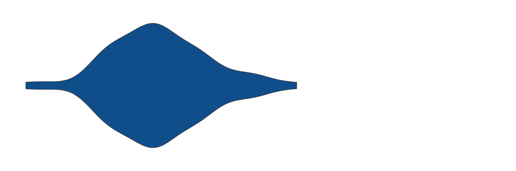

Gentoo

3950

5092.44

6300

[figure not shown]

**Solution**

```r
plot_density_species <- function(my_species) {
  full_range <- filtered_penguins |>
    pull(body_mass_g) |>
    range()

  filtered_penguins |>
    filter(species == my_species) |>
    ggplot(aes(x = body_mass_g, y = species)) +
    geom_violin(fill = 'dodgerblue4') +
    theme_minimal() +
    scale_y_discrete(breaks = NULL) +
    scale_x_continuous(breaks = NULL) +
    labs(x = element_blank(), y = element_blank()) +
    coord_cartesian(xlim = full_range)
}
plot_density_species("Adelie")
```

[figure not shown]

Notice that I have set the coordinate system of the plot to the full range of the data (regardless of the species). This part is important. Without this trick, the three plots would not share a common x-axis.

Ok, so now we have a function that creates the desired plots. Time to apply it to our table. For this to work, we need an additional column that we can target. So we use `mutate()` to add a new column, then `text_transform()` to turn this column into images, and finally `.fn` argument can be supplied with our function iterated over each species with `map()`.

```r
penguin_weights |>
  mutate(Distribution = Species) |>
  gt() |>
  tab_spanner(
    label = 'Penguin\'s Weight',
    columns = -Species
  ) |>
  text_transform(
    locations = cells_body(columns = 'Distribution'),
    fn = function(column) {
      map(column, plot_density_species) |>
        ggplot_image(height = px(50), aspect_ratio = 3)
    }
  )
```

Species

Penguin's Weight

Min

Mean

Max

Distribution

Adelie

2850

3706.16

4775

[figure not shown]

Chinstrap

2700

3733.09

4800

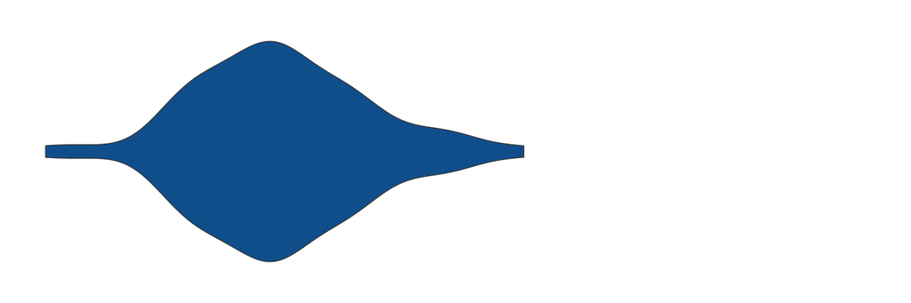

Gentoo

3950

5092.44

6300

[figure not shown]

## 7.29 Conclusion

Many of the tweaks we made to our table are quite subtle. Changes like removing excess gridlines, bolding header text, right-aligning numeric values, and adjusting the level of precision can often go unnoticed, but if you skip them, your table will be far less effective. Our final product isn’t flashy, but it does communicate clearly.

We used the gt package to make our high-quality table, and as we’ve repeatedly seen, this package has good defaults built in. Often, you don’t need to change much in your code to make effective tables. But no matter which package you use, it’s essential to treat tables as worthy of just as much thought as other kinds of data visualization.

Later you’ll learn how to create reports using R Markdown, which can integrate your tables directly into the final document.

## 7.30 Reading

Consult the following resources to learn about table design principles and how to make high-quality tables with the gt package:

["gt package intro"](https://gt.rstudio.com/articles/gt.html)

“Ten Guidelines for Better Tables” by Jon Schwabish (Journal of Benefit-Cost Analysis, 2020), https://doi.org/10.1017/bca.2020.11

“10+ Guidelines for Better Tables in R” by Tom Mock (2020), https://themockup.blog/posts/2020-09-04-10-table-rules-in-r/